# DL1 regression example

ใน python สามารถรันทั้ง python และ R ไขว้กันไปมาได้นะ สำหรับคนที่ไม่ถนัด python มากนัก สามารถใช้ R นำเข้าจัดกระทำข้อมูล แล้วมาเชื่อมกับ python ได้เลย ค่อนข้างสะดวก

```python
%load_ext rpy2.ipython
```

1. นำข้อมูลเข้า
2. จัดกระทำข้อมูล

```python
%%R

library(caret)
dat<-read.csv("/Users/siwachoat/Library/Mobile Documents/com~apple~CloudDocs/เอกสารประกอบการสอน/Machine Learning/เอกสาร/ep2_regression/_02_multiple regression/crimm.csv")
dat<-dat[,-1]
dat[,1:16]<-scale(dat[,1:16], center=TRUE, scale=TRUE)
str(dat)
```

```
'data.frame':	2212 obs. of  17 variables:
 $ householdSize         : num  1.175 0.337 -0.829 -0.919 0.158 ...
 $ pct.lao               : num  -0.559 -0.599 -0.603 -0.536 -0.618 ...
 $ pct.thai              : num  0.474 0.705 0.629 0.813 0.315 ...
 $ pct.myanmar           : num  0.855 0.172 0.169 -0.485 -0.336 ...
 $ pct.cambodia          : num  -0.415 -0.485 -0.383 -0.496 -0.508 ...
 $ numPop.urban          : num  -0.1739 -0.1197 -0.0895 -0.2321 -0.2321 ...
 $ medIncome.household   : num  3.063 1.037 0.125 -0.999 -1.237 ...
 $ pctWPubAsst           : num  -1.227 -0.861 -0.821 1.044 0.938 ...
 $ pctPop.poor           : num  -1.123 -0.888 -0.798 0.654 2.14 ...
 $ pchLessM3             : num  -0.506 -0.536 -0.958 0.281 0.447 ...
 $ PctUnemployed         : num  -1.155 -1.248 -0.702 1.319 1.049 ...
 $ NumIlllegal.labor     : num  -0.0903 -0.0787 -0.0868 -0.1072 -0.1098 ...
 $ HousVacant            : num  -0.259 -0.232 -0.185 -0.166 -0.217 ...
 $ Num.HomelessInShelters: num  -0.0993 -0.1187 -0.0904 -0.1187 -0.1152 ...
 $ Num.HomelessInStreet  : num  -0.0727 -0.0727 -0.0727 -0.0727 -0.0727 ...
 $ PopDens               : num  -0.33155 -0.21117 -0.00127 0.15303 -0.63948 ...
 $ TheifperPop           : num  115 242 758 1302 729 ...
```

- แบ่งชุดข้อมูลเป็น train และ test data
- convert R matrix ให้เป็น numpy array ใน python

```python
%%R

train.id<-createDataPartition(dat$TheifperPop, p = 0.8 , list=F)
train_x<-as.matrix(dat[train.id, 1:16])
train_y<-as.numeric(dat[train.id, 17])

test_x<-as.matrix(dat[-train.id, 1:16])
test_y<-as.numeric(dat[-train.id, 17])
```

```python
import pandas as pd
# convert R matrix into numpy array
train_x = %R train_x
train_y = %R train_y

test_x = %R test_x
test_y = %R test_y

display(type(train_x))
display(type(train_y))
```

```
numpy.ndarray
```

```
numpy.ndarray
```

**Create DL Model in Python**

```python
from keras.models import Sequential
from keras.layers import Dense

#1. Create a Sequential model
model = Sequential()

#2. Add an input layer and a hidden layer with 2 neurons.
model.add(Dense(units = 32, input_shape=[16],
                activation="relu"))

# Add 16-neuron hidden layer
model.add(Dense(units = 16,activation="relu"))

# Add 1-neuron output layer
model.add(Dense(units = 1))

#4. model summary
model.summary()
```

```
Model: "sequential_12"
_________________________________________________________________
Layer (type)                 Output Shape              Param #
=================================================================
dense_35 (Dense)             (None, 32)                544
_________________________________________________________________
dense_36 (Dense)             (None, 16)                528
_________________________________________________________________
dense_37 (Dense)             (None, 1)                 17
=================================================================
Total params: 1,089
Trainable params: 1,089
Non-trainable params: 0
_________________________________________________________________
```

พิจารณาผลลัพธ์ใน `model.summary()` ข้างต้น จะเห็นว่า DL model ที่สร้างขึ้นประกอบด้วย

- input layer ที่มี neuron จำนวน 16 หน่วย
- hidden layer 2 ชั้น โดยที่ ชั้นแรกมี 32 neurons และชั้นที่สองมี 16 neurons
- output layer มี 1 neuron

พารามิเตอร์ที่ใช้แปลงข้อมูลจาก input layer มาที่ hidden layer ชั้นแรก มีจำนวน 544 พารามิเตอร์ ประกอบด้วย weight parameters จำนวน 32 x16 = 512 ตัว และ bias parameters จำนวน 32 ตัว รวมเป็น 512+32 = 544 ตัว

และพารามิเตอร์ที่แปลงข้อมูลจาก hidden layer ชั้นที่สองไปยัง output layer จำนวน 16+1 = 17 ตัว

รวมเป็น 1089 ตัว

```python
#5. compile and train the model
model.compile(optimizer = "adam", loss = "mse")
```

```python
#6. Train the model
history = model.fit(train_x, train_y,  epochs=1000, verbose=0)
```

[output not shown]

[output not shown]

**ประเมินคุณภาพของโมเดล**

```python
## Evaluation metrics
mse = model.evaluate(test_x, test_y)
import math
display(mse) #MSE value
display(math.sqrt(mse)) #RMSE value
```

[output not shown]

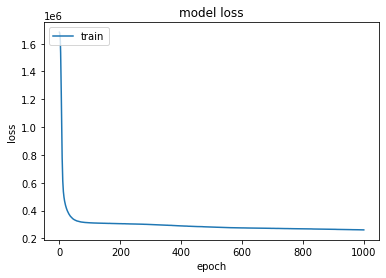

```python
import matplotlib.pyplot as plt

## plot of loss on the training datasets over training epochs.
plt.plot(history.history['loss'])
plt.title('model loss')
plt.ylabel('loss')
plt.xlabel('epoch')
plt.legend(['train', 'test'], loc='upper left')
plt.show()
```

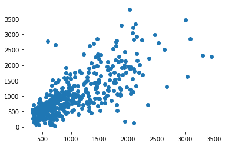

```python
# calculate predicted value
pred_test = model.predict(test_x)
plt.scatter(pred_test, test_y)
plt.show()

# push predicted values to R object
%Rpush pred_test
%Rpush test_y
```

```python
%%R
library(dplyr, versbose=F)
paste("correlation is equal to", cor(pred_test, test_y))%>%print()
paste("R2 is equal to", cor(pred_test, test_y)^2)%>%print()
```

```
[1] "correlation is equal to 0.732619323633864"
[1] "R2 is equal to 0.536731073361741"
```

แบ่งชุดข้อมูลทดสอบในแต่ละ epoch

```python
#1. Create a Sequential model
model = Sequential()

#2. Add an input layer and a hidden layer with 2 neurons.
model.add(Dense(units = 32, input_shape=[16],
                activation="relu"))

# Add 16-neuron hidden layer
model.add(Dense(units = 16,activation="relu"))

# Add 1-neuron output layer
model.add(Dense(units = 1))

#4. model summary
model.summary()

#5. compile and train the model
model.compile(optimizer = "adam", loss = "mse")

#6. Train the model
history = model.fit(train_x, train_y,  epochs=500, verbose=1, validation_split=0.2)
```

```
Model: "sequential_15"
_________________________________________________________________
Layer (type)                 Output Shape              Param #
=================================================================
dense_44 (Dense)             (None, 32)                544
_________________________________________________________________
dense_45 (Dense)             (None, 16)                528
_________________________________________________________________
dense_46 (Dense)             (None, 1)                 17
=================================================================
Total params: 1,089
Trainable params: 1,089
Non-trainable params: 0
_________________________________________________________________
```

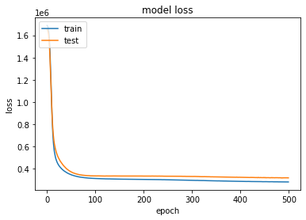

```python
# Review model's progress
plt.plot(history.history['loss'])
plt.plot(history.history['val_loss'])
plt.title('model loss')
plt.ylabel('loss')
plt.xlabel('epoch')
plt.legend(['train', 'test'], loc='upper left')
plt.show()
```